# Snowshoe Hares: Exporatory Report

Joaquin Meckler

11/17/2020

### a. Introduction

This report focuses on changes in population levels in juvenile Snowshow Hares (*Lepus americanus*) across a 13 year span, depicting a likely overall decrease in species counts from 1999 to 2012. Additionally, it looks at the relationship between trap location and weight across sex identification as well as the correlation between hind foot length and weight. Acting as a keystone prey species, snowshoe hares can significantly alter ecosystems through changes in their individual population levels. Often viewed as indicators of ecosystem heath, keystone species can provide valuable information on how entire ecosystems respond to environmental changes. The three site locations this report focuses on are a Riparian site, a Mature Forest site, and a Black Spruce site.

### b. Data and Analyses

This [data](https://doi.org/10.6073/pasta/03dce4856d79b91557d8e6ce2cbcdc14) was collected by Dr. Knut Kielland, senior investigator for the Institute of Arctic Biology, and several primary investigators at the Bonanza Creek Experimental Forest location within the Long Term Ecological Research Network. The data contains 3197 total observations from capture-recapture studies at 5 locations within the Tanana Valley from 1999 to 2012. Juvenile mean weight differences between males and females are determined using a Welch’s two-sample t-test with a significance level ($\alpha$) of 0.05 throughout. Differences between groups are described by Cohen’s *d* effect size. The relationship between hind foot length and weight is explored by simple linear regression. All analyses are in R version 4.0.2 using R Studio version 1.3.1073.

## c. Exploratory Findings

### i. Annual Juvenile Hare Trap Counts

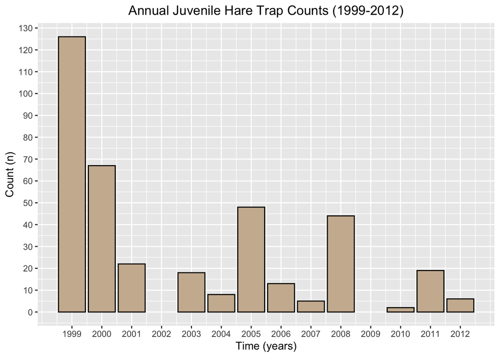

### Interpretation of Results

Figure 1 displays the annual counts of juvenile snowshow hares across time. The counts range from a maximum of 126 to a minimum of 2. The mean across all years is 31.5 with a median of 18.5. Year 2002 and 2009 display no count records due to no juvenile snowshoe hares being identified as juveniles after being trapped. Including a zero for those years would create the assumption that there were no juveniles trapped in a given year, which would be inaccurate due to the uncertainty that exists for the two years with zero counts being shown. After an initial peak in counts in 1999, the overall trend shows the number of snowshow hares decreaseing over time from that point on with several intermittent spikes in 2005 and 2008. As the number of absolute counts are impacted by effort, it would be recommended to quantify this through setting a limit on trapping days or number of traps set. This would account for any discrepancies in effort across years. Additionally, several individuals were recaptured in a single year, thus the overall count is slightly lower then our data shows.

### ii. Juvenile Hare Weights

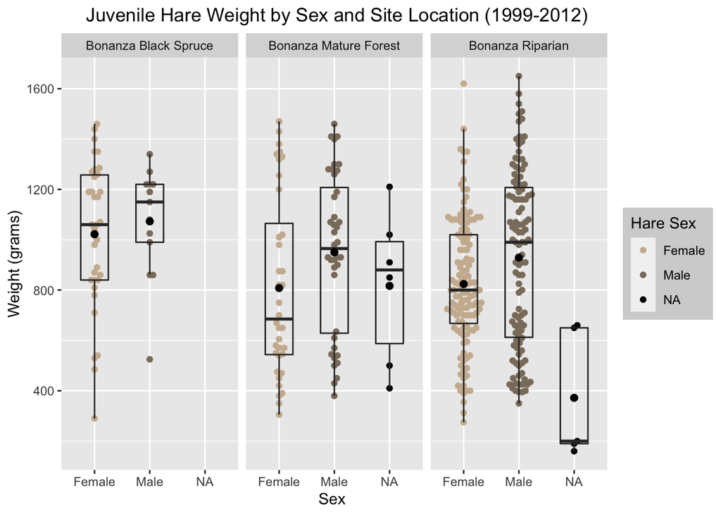

**Figure 2.** Comparison of juvenile Snowshow Hare weight (grams) across three sites (Bonanza Riparian, Bonanza Mature Forest and Bonanza Black Spruce) by sex. The x-axis displays the sex, with a NA column for unidentified individuals. The black circle represents the mean weight for each sex at each site while the black line represents the median. Box endpoints indicate the 25<sup>th</sup> and 75<sup>th</sup> percentile values.

### iii. Further Juvenile Weight Comparison Among Male & Female Hares

**Table 1** Table 1 displays the mean male and female +/- the standard deviation for juvenile snowshow hares across all site locations from 1999 to 2012. The population total was 163 and 197 for males and females, respectively.

[output not shown]

## iv. Relationship Between Juvenile Weight & Hind Foot Length

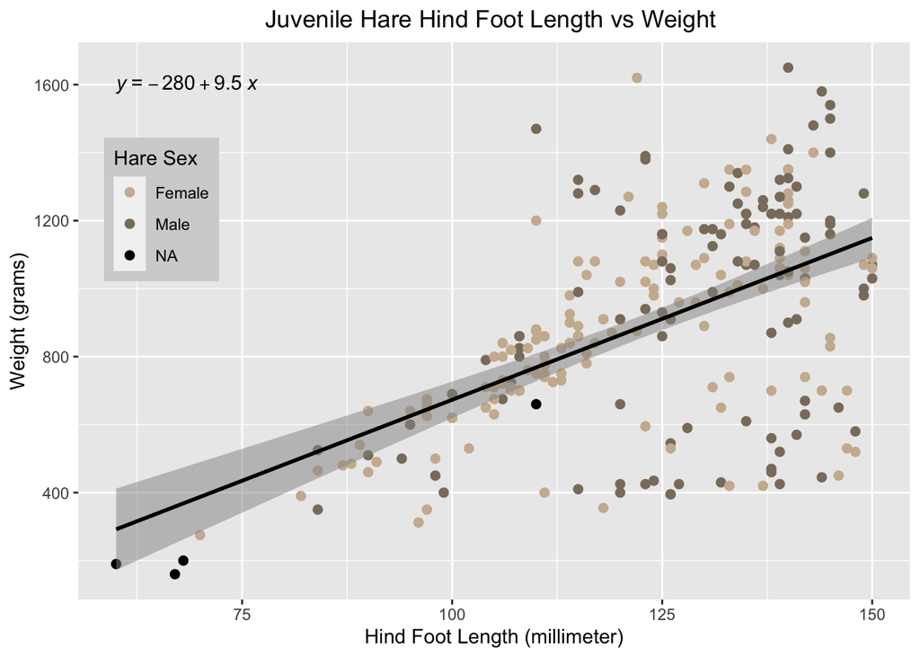

**Figure 3.** Figure 3 displays the linear relationships between hind foot length (mm) and weight (gram) among male and female snowshoe hares across all site locations (n=378). The equation for this relationship is summarized as follows: Linear model summary: $\beta$<sub>1</sub> = 9.52 g mm<sup>-1</sup>, p < 0.001, R<sup>2</sup> = 0.3, Pearson’s *r* = 0.55).

### Interpretation of Results

Using a linear regression, it is found that the relationship between hind foot length (mm) and weight (grams) can be expressed, on average, as hind foot length increases by 1mm, weight will increase by 9.5 grams. The R<sup>2</sup> value of 0.3 indicates that dependent (weight) variable largely cannot be predicted by the value of the independent (hind foot length) variable and there is little correlation between variables. This means 30% of the variance within the weight can be predicted using our model. However, it is important to take into account that the residuals display Heteroscedasticity, thus the predictions we make may be over- or underestimating uncertainty.This is further supported by looking at the residual variances, which display changes over the range of fitted values. As the observations are independent of each other, it is not anticipated that errors in one observation will influence errors for any other observations. Similarly, the Cook’s distance measurement shows that there are not outliers that influence the data. Lastly, looking at a Q-Q plot, it appears the residuals are not normally distributed. It is possible that a exponential or logarithmic regression may better fit the data patterns.

### Next steps

- To account for effort differences, it is recommended to normalize trapping efforts through setting a certain number of traps or trapping for a certain number of days each year. This will help confirm if the population fluctuations exhibited are fully explained by data.
- A exponential or logarithmic regression may better fit the data patterns.

### Citations

Kielland, K., Chapin, F. S., Ruess, R. W., & Bonanza Creek LTER. (2017). Snowshoe hare physical data in Bonanza Creek Experimental Forest: 1999-Present [Data set]. Environmental Data Initiative. https://doi.org/10.6073/PASTA/03DCE4856D79B91557D8E6CE2CBCDC14